# RR2

# 8.Histogram of the total number of steps taken each day after missing values are imputed.

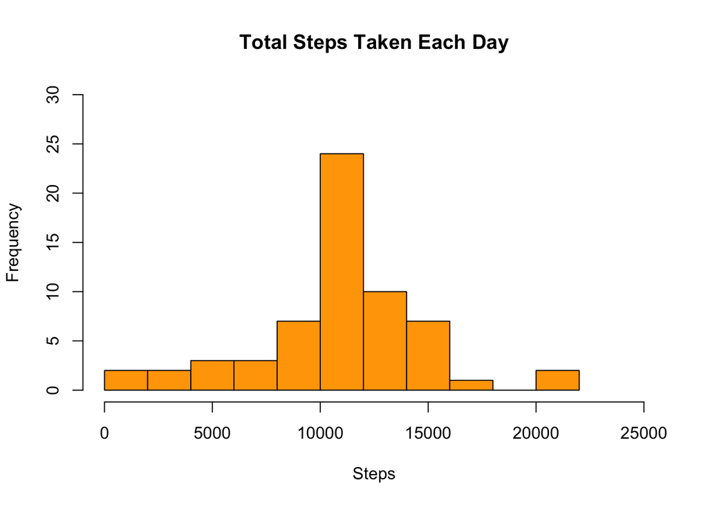

```r
new_step_sum<-tapply(newActivity$steps,newActivity$date,sum)
hist(new_step_sum,col = "orange",breaks=10,main="Total Steps Taken Each Day",xlab = "Steps",xlim=c(0,25000),ylim=c(0,30))
```

Mean and median of the number of steps taken each day for the new dataset

```r
newMean<-mean(new_step_sum,na.rm=TRUE)
newMedian<-median(new_step_sum,na.rm=TRUE)
```

After imputing the missing values, the new mean keeps unchanged while the new median increases when compare to the original dataset “activity”. In general, the changing is negligible.

# 10.Panel plot comparing the average number of steps taken per 5-minute interval across weekdays and weekends

Create a new factor variable in the dataset with two levels.

```r
newActivity$date<-as.POSIXct(newActivity$date)
newActivity$day<-"Weekdays"
newActivity$day[weekdays(newActivity$date) %in% c("Saturday", "Sunday")] <- "Weekend"
```

Make a panel plot containing a time series plot.

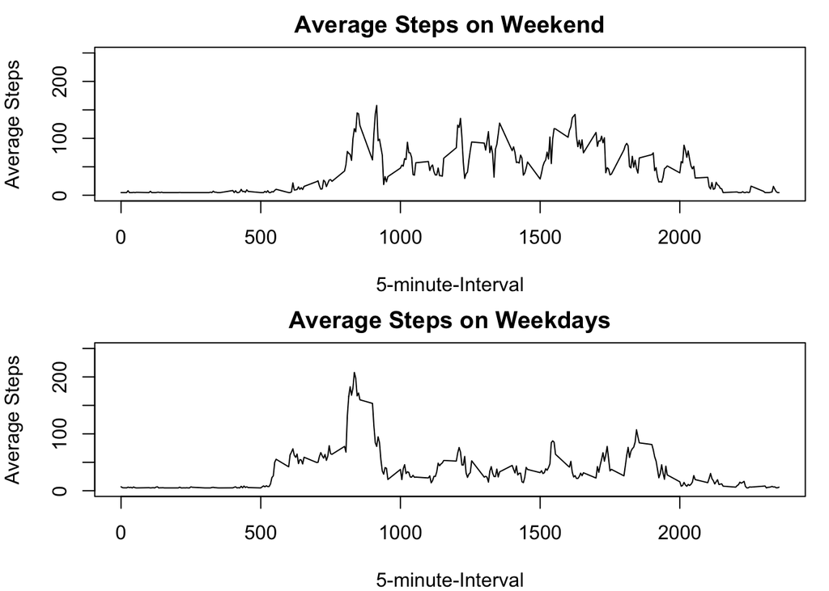

```r
par(mfrow=c(2,1),mar=c(4,4,2,1))
Weekend<-subset(newActivity,day=="Weekend")
WeekendMean<-tapply(Weekend$steps,Weekend$interval,mean)
Weekdays<-subset(newActivity,day=="Weekdays")
WeekdaysMean<-tapply(Weekdays$steps,Weekdays$interval,mean)
plot(names(WeekendMean),WeekendMean,type="l",ylim=c(0,250),xlab = "5-minute-Interval",ylab = "Average Steps",main = "Average Steps on Weekend")
plot(names(WeekdaysMean),WeekdaysMean,type = "l",ylim=c(0,250),xlab = "5-minute-Interval",ylab = "Average Steps",main = "Average Steps on Weekdays")
```